# Inferring diversity patterns along an elevation gradient from stacked SDMs: A case study on Mesoamerican ferns - ScienceDirect

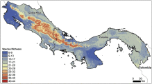

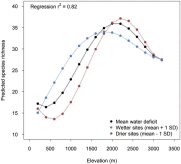

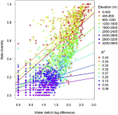

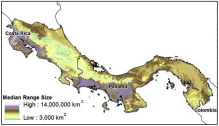

1. Table A1

1. Online data

## [Global Ecology and Conservation](https://www.sciencedirect.com/science/journal/23519894)

[Volume 16](https://www.sciencedirect.com/science/journal/23519894/16/supp/C), October 2018, e00433

# Original Research Article Inferring diversity patterns along an elevation gradient from stacked SDMs: A case study on Mesoamerican ferns

[Mindy M.Syfert<sup>a</sup><sup>b</sup>](https://www.sciencedirect.com/science/article/pii/S2351989418300921#!)[Neil A.Brummitt<sup>a</sup>](https://www.sciencedirect.com/science/article/pii/S2351989418300921#!)[David A.Coomes<sup>b</sup>](https://www.sciencedirect.com/science/article/pii/S2351989418300921#!)[NadiaBystriakova<sup>c</sup>](https://www.sciencedirect.com/science/article/pii/S2351989418300921#!)[Matthew J.Smith<sup>d</sup>](https://www.sciencedirect.com/science/article/pii/S2351989418300921#!)

Under a Creative Commons [license](https://creativecommons.org/licenses/by-nc-nd/4.0/)

open access

## Abstract

An enduring challenge in ecology is to characterise and understand [species richness](https://www.sciencedirect.com/topics/earth-and-planetary-sciences/species-richness) patterns in tropical regions. Species richness maps produced by stacking [species distribution model](https://www.sciencedirect.com/topics/earth-and-planetary-sciences/environmental-niche-modeling) (SDM) range maps could prove useful in this regard, but little attention has been given to this approach. Here we generate a species richness map by stacking the ranges of 86 Mesoamerican [fern](https://www.sciencedirect.com/topics/agricultural-and-biological-sciences/fern-ally) species modelled by MaxEnt from field data collected by the Sampled Red List Index for Plants project. Predicted species richness showed a hump-backed relationship with elevation, peaking at mid-elevation (1800–2000 m). A remarkably similar pattern was observed in a field survey conducted to validate the approach. Predicted species richness was also low in sites with high water deficits, as previously shown in the fern literature. Beta-diversity in the lowlands was greatest between sites with strongly contrasting water deficits, further emphasising the importance of this environmental variable. The stacked SDM approach was thus able to reproduce broad biogeographical patterns of species richness, despite many of the fern species being represented by fewer than 20 samples.

## Keywords

MaxEnt

Mesoamerican ferns

Sampled red list index (SRLI)

Species distribution models (SDMs)

## 1. Introduction

Despite the highest numbers of species on land occurring in moist tropical forests (Pimm et al., 2001), little detail is known about [species richness](https://www.sciencedirect.com/topics/earth-and-planetary-sciences/species-richness) patterns in many of tropical forest regions (Kessler et al., 2011a). Biodiversity data for many taxonomic groups are under-represented throughout the tropics (Collen et al., 2008; Zamin et al., 2010), yet it is in these regions that future losses of biodiversity are predicted to be greatest (Collen et al., 2008). Gaining a greater understanding of species richness patterns is particularly important for tropical regions as conversion of forests to agricultural lands is occurring at high rates (DeFries et al., 2005) and protection of biodiverse areas within increasingly agricultural landscapes is essential in attempts to reduce species loss.

Although species richness (alpha diversity) is one of the most widely used measures of biodiversity, understanding the causes of [spatial variation](https://www.sciencedirect.com/topics/earth-and-planetary-sciences/spatial-variation) in biodiversity continues to be a major challenge in ecology. Empirical studies of trends in species richness with elevation have shown that it either: 1) decreases monotonically with elevation; 2) stays relatively constant from low to mid elevations and then decreases sharply at higher elevations; or 3) is “hump-shaped” i.e. peaks at mid elevation (Rahbek, 1995, 2005). A review of 204 elevation gradients around the world found that in 80% of the studies the trend was hump-shaped (Rahbek, 2005). Explanations for these trends focus on the filtering effects of climate on species' occurrence (Hawkins et al., 2003). One explanation is that tropical mountains have cloud condensation (i.e. fog) zones at mid-elevations (Hastenrath, 1967), creating high humidity conditions ideal for plant life that support many tropical [fern](https://www.sciencedirect.com/topics/agricultural-and-biological-sciences/fern-ally) species (Page, 2002; Kessler et al., 2011b) and other [epiphytes](https://www.sciencedirect.com/topics/earth-and-planetary-sciences/epiphyte) which favour humidity (Gentry and Dodson, 1987; Rahbek, 1995). Other studies suggest that a combination of water availability and temperature determines species distributions and species richness in mountains (O'Brien, 1993, 2006), with low temperatures limiting species richness at high elevations, and low water availability (i.e. reduced humidity and periodic droughts) limiting species richness at low elevations (Bhattarai et al., 2004; Kluge et al., 2006). It has been suggested that such water-energy constraints are responsible for elevational trends in the species richness of birds, [small mammals](https://www.sciencedirect.com/topics/agricultural-and-biological-sciences/small-mammals), bats and ferns (McCain, 2005, 2007, 2009; Kessler et al., 2011b). [Anthropogenic effects](https://www.sciencedirect.com/topics/earth-and-planetary-sciences/anthropogenic-effect) are also likely to be important, tending to be strongest a low elevations, reducing diversity, and decreasing with elevation (Nogués-Bravo, D. et al., 2008).

The variation of species composition across space (i.e. beta diversity *sensu* Whittaker, 1972) has been measured using many different indices (Koleff et al., 2003a). Recent reviews have distinguished between two types of indices for beta diversity (Anderson et al., 2011): (a) turnover indices quantify the change of community structure from one site to the next along a gradient, and is the focus of this study; (b) variation indices quantify the change of community composition among a set of sites within a spatial (or temporal) extent or habitat (Anderson et al., 2011). In general beta diversity is interpreted as a reflection of the degree of habitat specialization among species: high beta diversity is often associated with steep gradients, topographic complexity, variation in geological and environmental history, narrow environmental tolerances and small range sizes. Many studies have found that beta diversity increases towards the equator and is greater in the lowlands than at higher elevations (see Koleff et al., 2003b for a review); it also has been noted as decreasing from high-to low-diversity regions (Myers et al., 2013).

Most analyses of biodiversity patterns along [environmental gradients](https://www.sciencedirect.com/topics/earth-and-planetary-sciences/environmental-gradient) are based on field data collected in transects or plots, but an emerging alternative or complementary approach is to use stacked [species distribution models](https://www.sciencedirect.com/topics/earth-and-planetary-sciences/environmental-niche-modeling) (SDMs) (D'Amen et al., 2017; Calabrese et al., 2014; Distler et al., 2015; Mateo et al., 2016). Species distribution models formally relate documented locations and environmental information to predict a species' suitability of occurrence across a landscape. Often the suitabilities are converted to binary maps containing species presences and absences; the presences can be summed (or stacked) to provide a bottom-up estimate of species richness (predict first assemble later; Ferrier and Guisan, 2006). More recently the maps of suitabilities have been stacked as well (e.g. Cord et al., 2014). Stacked SDM maps of diversity are increasingly used to predict how potential species richness may change in mountain floras as a result of climate change (Engler et al. 2009, 2011; Randin et al., 2009), but only recently have studies begun investigating the use of stacked SDMs to predict biodiversity patterns along ecological gradients such as elevation (Mateo et al., 2012). Studies have investigated the performance of stacked SDMs in predicting biodiversity patterns and suggest that the approach can provide useful predictions of species richness patterns even if individual distribution models are not completely accurate (Pineda and Lobo, 2009; Mateo et al., 2012). None has yet investigated whether or not it is a practical approach for predicting species richness patterns when available data is limited.

Most plant species are only known from a few recorded localities (Rivers et al., 2011) and, thus, their true ranges are poorly understood. This has given rise to studies of whether reliable species distribution estimates can be obtained using low quantities of species locality data (e.g. Proosdij et al., 2016; Wisz et al., 2008). Less well studied is whether macroecological patterns in a given area can be reliably characterised using multiple poorly-sampled species. This adds uncertainty when making research and policy decisions such as setting conservation priorities. If macroecological patterns can be reliably characterised then it would open up the possibility of allowing more value to be obtained from currently available datasets. For example, the plant data for the Sampled Red List Index (Brummitt et al. 2008, 2015b), collected to provide an indication of rates of change of plant diversity, has locality data for species around the world, of which the majority of the 21% of threatened species each have fewer than 10 documented localities. To what extent could such a dataset be used to deduce other useful information such as regional patterns in species richness? It was such a question that inspired this study.

The aim of this study is to test whether species richness patterns predicted by the stacked SDM approach produce realistic diversity patterns for data-poor regions. We focus on 95 species from Costa Rica and Panama selected and studied for the Sampled Red List Index for Plants (Brummitt et al. 2008, 2015b). An advantage of this dataset is that species were chosen at random to be broadly representative taxonomically and geographically of plant species worldwide (Baillie et al., 2008), and available specimen data from across their global ranges have been compiled. Here we build stacked SDMs using these data and compare the modelled predictions with patterns obtained from two independent sources: 1) species richness patterns cited in literature which were derived from transect data, 2) our own field-collected data on fern richness for the montane ecoregions of Costa Rica. We also assess range size patterns across the study extent. Finally, we investigate whether stacked SDMs can provide insights into the climatic drivers of species richness (alpha diversity) and species turnover (beta diversity) along elevational gradients. In particular, we explore the hypothesis that low temperatures are an important influence at high elevations, whilst water availability becomes important at low elevations.

## 2. Methods

### 2.1. Occurrence data and environmental variables

We selected species occurrence data from the plant component of the Sampled Red List Index (SRLI), an indicator to measure the current rate of loss of biodiversity by tracking trends in the conservation status of a randomly-selected sample of species (see details in: Baillie et al., 2008; Brummitt et al., 2008; Brummitt et al. 2015a; Brummitt et al. 2015b). We focused on pteridophyte (fern) SRLI species occurring in Costa Rica and Panama, within the Mesoamerica biodiversity hotspot (Myers et al., 2000) and a region of particularly high endemism for ferns globally (Brummitt et al., 2016). Many species in this region are poorly represented in the world's [herbaria](https://www.sciencedirect.com/topics/earth-and-planetary-sciences/herbarium), so knowledge of their true distribution is limited, but every effort was made to collate all available specimen information for these species. The SRLI [fern](https://www.sciencedirect.com/topics/agricultural-and-biological-sciences/fern-ally) dataset comprises specimen data predominantly from the Natural History Museum, London (NHM), supplemented by other web-based digital repositories such as Global Biodiversity Information Facility (GBIF) or online catalogues of individual institutions such as the TROPICOS database of Missouri [Botanical Garden](https://www.sciencedirect.com/topics/earth-and-planetary-sciences/botanical-garden), and specific additional localities taken from literature sources for species where other data were few. Significant effort has gone into ensuring the validity of the identifications and the species localities of records present in the dataset, through expert verification and precise geo-referencing, in the course of undertaking detailed IUCN Red List assessment of the [extinction risk](https://www.sciencedirect.com/topics/earth-and-planetary-sciences/extinction-risk) facing these species (see details in: Brummitt et al., 2008; Brummitt et al. 2015a; Brummitt et al. 2015b). However, it is nonetheless the case that a number of these species are known from few records.

The dataset for Costa Rica and Panama originally contained 95 fern species, spanning a wide range of life forms ranging from small [epiphytes](https://www.sciencedirect.com/topics/earth-and-planetary-sciences/epiphyte) to terrestrial tree ferns, although almost half are epiphytic. This original dataset was reduced to 86 species due to our inability to obtain accurate model predictions for some (detailed below). As a consequence, the dataset we used in this study contained 86 fern species with sample sizes ranging from 5 to 200 specimens, with 85% of species having sample sizes of 10 or more (Table A1). While model accuracy has been found in other studies to decrease rapidly for sample sizes of fewer than 10 specimens (Stockwell and Peterson, 2002; Wisz et al., 2008) we chose to leave in the small proportion of species with sample sizes of fewer than 10 specimens for which we could obtain sufficiently accurate predictions. Reducing the number of species to only those with sample sizes of 10 records or more had no qualitative effect on our results.

Annual bioclimatic variables were obtained from the Worldclim database, version 1.4 (http://www.worldclim.org; Hijmans et al., 2005) and from the Consultative Group for International Agricultural Research Consortium for Spatial Information (CGIAR-CSI; http://www.cgiar-csi.org), datasets frequently used in [species distribution modelling](https://www.sciencedirect.com/topics/earth-and-planetary-sciences/environmental-niche-modeling) studies. A subset of environmental variables were selected based on a combination of correlation, principal components and cluster analyses (Syfert et al., 2013) to reduce the degree of multi-collinearity (Franklin, 2009), as well as using expert judgement based on the ecology of the taxa (Elith and Leathwick, 2009). Thus to build the SDMs we selected a subset of 5 variables from an initial pool of 24 environmental variables: mean annual actual evapotranspiration, mean annual water deficit (calculated as PET-AET; Stephenson, 1998), minimum temperature of the coldest month, precipitation of the coldest quarter and precipitation of the warmest quarter. These temperature-and water-based variables represent factors commonly known to constrain species distributions (Austin, 2002). All variables had a 30 arc second (∼1 km at the Equator) [spatial resolution](https://www.sciencedirect.com/topics/earth-and-planetary-sciences/spatial-resolution). These bioclimatic variables will have errors in their estimates, especially for precipitation in the mountainous regions (Hijmans et al., 2005); however, for the purposes of this study these will be relatively small compared to the large variations in temperature and precipitation experienced by our different study species over the large elevational range of our study (from sea level to >3200 m).

### 2.2. Stacked species distribution models

We used MaxEnt software to build species distribution models (Version 3.3.3; Phillips et al., 2009; see also Phillips and Dudik, 2008; Elith et al., 2011 for details) because it performs well with presence-only data, even with low numbers of known presence localities (Elith et al., 2006; Hernandez et al., 2006; Pearson et al., 2007). In previous studies we have found that using linear and quadratic functional forms reliably produces relatively simple models that do not over-fit the training data (Merow et al., 2013; Syfert et al., 2013), rather than experimenting with the regularisation parameter (Cao et al., 2013). Sampling bias was controlled for by including a sampling bias dataset (Phillips et al., 2009; Syfert et al., 2013) constructed from all georeferenced [vascular plant](https://www.sciencedirect.com/topics/earth-and-planetary-sciences/vascular-plant) occurrence data from the GBIF data portal (last accessed February 2016) and from the SRLI project.

An intuitive way to estimate [species richness](https://www.sciencedirect.com/topics/earth-and-planetary-sciences/species-richness) from species distribution models is to sum each of the range maps (i.e. binary maps of predicted presences and absences) predicted for each of the individual species. Such range maps are produced by applying a threshold to the predicted suitability indices (or probabilities of occurrence). In this study we created such range maps using a maximum sensitivity and specificity approach to threshold the suitabilities of occurrence (Liu et al. 2005, 2013). In a previous study we showed that the advantage of such range maps is that they can capture the true distribution of the species more accurately than a simple polygon drawn around the known presences (Syfert et al., 2014). However, a disadvantage of summing such range maps is that they generate a biased estimate of species richness (Calabrese et al., 2014). We therefore used both approaches – summing species range maps and summing species suitability maps – and found species richness estimates to be highly correlated (reported below). This is supported by previous studies that showed a positive relationship between estimates from both methods, despite stacked range maps producing a more biased estimate (summarised in Calabrese et al., 2014). Our focus in this study is on whether or not our stacked species distribution models can capture the qualitative pattern of species richness variation with latitude, and hence we would obtain the same result irrespective of the method used.

### 2.3. Analysis of species richness patterns along an elevational gradient

Environmental drivers of species richness were evaluated by multiple regression. [Elevation data](https://www.sciencedirect.com/topics/earth-and-planetary-sciences/datum-elevation) was obtained from the Worldclim database and re-classified into 200 m bands for the whole study extent, and 100 points were then randomly extracted from the elevation raster and species richness raster for analysis. The predicted species richness of grid cells was modelled as a function of elevation and water deficit using least-squares regression (the *lm* function in R). Various alternative models were evaluated by their adjusted R<sup>2</sup> values and the most parsimonious was selected.

### 2.4. Beta diversity patterns

To test whether or not grid cells that were most different in water balance were also most different in species composition, we correlated $βjac$ values with differences in water deficit (|Δwater deficit|) between the pairs of grid cells. This analysis was conducted within 400 m elevation bands, in order to distinguish the effects of elevation from those of water deficit.

### 2.5. Geographic range sizes

The Extent of Occurrence (EOO) of a species is one of two standard measures of geographic range (Gaston, 1991) that is defined as the area that lies within the outermost limits of known locations for a species (Gaston and Fuller, 2009), and is often measured as a minimum convex polygon (MCP) around known species localities (although studies have assessed alternative methods, e.g. Burgman and Fox, 2003; Willis et al., 2003; Callmander et al., 2007). MCPs were calculated for each species using all locality data from the SRLI dataset and its area recorded (Table A1). For each pixel in the stacked SDM grid, we recorded which species were predicted to be present and then calculated the mean, median, minimum and maximum geographic ranges of those species. Patterns of median range size were then investigated.

## 3. Results

### 3.1. Species distribution modelling and stacked-SDM maps

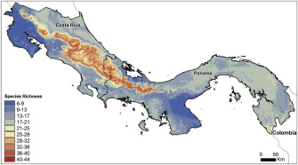

Fig. 1. A map of [fern](https://www.sciencedirect.com/topics/agricultural-and-biological-sciences/fern-ally) [species richness](https://www.sciencedirect.com/topics/earth-and-planetary-sciences/species-richness) for Costa Rica and Panama, derived by stacking [species distribution models](https://www.sciencedirect.com/topics/earth-and-planetary-sciences/environmental-niche-modeling) generated for 86 species. Blue colours represent low richness while red colours represent high species richness (i.e. 40–44 of the 86 species predicted to be present with a 1 km<sup>2</sup> grid cell). (For interpretation of the references to colour in this figure legend, the reader is referred to the Web version of this article.)

### 3.2. Species richness patterns and trends along elevation

Most 1km<sup>2</sup> grid cells were predicted to contain 10-14 species of the 86 species than had been modelled, with the maximum number of 42 species occurring in one cell. Mean species richness per grid cell peaked in the 1800–2000m elevation band (Fig. 2a). The species richness of ferns observed within 14 field plots in Costa Rica is plotted in Fig. 2b alongside the predicted species richness for each site, extracted from the stacked-SDM map; here again we see similar trends in species richness between field and modelled datasets (albeit with different absolute values reflecting differences in sampling approaches). Hump-backed relationships have also been reported from transect studies conducted in this region, for ferns and [vascular plant](https://www.sciencedirect.com/topics/earth-and-planetary-sciences/vascular-plant) [epiphytes](https://www.sciencedirect.com/topics/earth-and-planetary-sciences/epiphyte), with the peak in richness coinciding with the cloud forest zone of the mountains characterised by persistent fog (Cardelus et al., 2006; Kluge et al., 2006; Watkins et al., 2006; Kessler et al., 2011b). In contrast, no clear trend was observed in mean numbers of species observed per altitude band in the unprocessed SRLI dataset (Fig. 2a). While the specimen data alone cannot capture observed patterns of species richness with altitude, a stacked-SDM map constructed from the same data captures the observed patterns well.

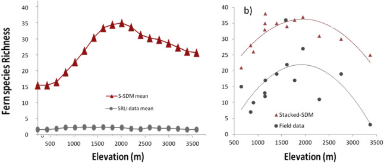

Fig. 2. Variation in [fern](https://www.sciencedirect.com/topics/agricultural-and-biological-sciences/fern-ally) [species richness](https://www.sciencedirect.com/topics/earth-and-planetary-sciences/species-richness) with elevation where: a) species richness is predicted by stacking maps produced by [species distribution modelling](https://www.sciencedirect.com/topics/earth-and-planetary-sciences/environmental-niche-modeling) (triangles) and counting the number of species within 200-m elevation classes held in the Sampled Red List Index dataset (circles); b) fern richness from field data collected in fourteen 260 m<sup>2</sup> plots in Costa Rica to compared with fern richness predicted by the from stacked SDM approach, selecting 1-km<sup>2</sup> grid cells centred on plot locations. Quadratic functions are fitted to the field-data and stacked SDMs using least squares regression. (For interpretation of the references to colour in this figure legend, the reader is referred to the Web version of this article.)

Regression analyses of the environmental determinants of species richness show that water deficit modulates the hump-backed elevation relationship (Fig. 3, Fig. 4). A division of the data into elevation bands shows that water deficit varies greatly among [lowland](https://www.sciencedirect.com/topics/agricultural-and-biological-sciences/lowlands) sites and that species richness is negatively correlated with water deficit at these altitudes (Fig. 3); by contrast, the water deficit is consistently low at high altitudes and does not influence species richness strongly (Fig. 3). Linear regression demonstrates that a cubic function of elevation and a quadratic function of water deficit (and interactions between variables) produced the most parsimonious model. A summary of the model is given in supplementary information; the model R2 of 0.83 indicates an excellent [goodness of fit](https://www.sciencedirect.com/topics/earth-and-planetary-sciences/goodness-of-fit). These analyses show that the humped-back species richness relationship is greatly affected by water deficit at [low altitudes](https://www.sciencedirect.com/topics/earth-and-planetary-sciences/low-altitude), but not at high altitudes (Fig. 4), and suggest that the peak in species richness descends further down mountainsides in regions with low water deficit (Fig. 4 and Fig. A4); this result is consistent with the fact that clouds form at lower altitude in wetter regions (Foster, 2001).

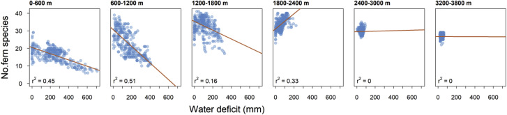

Fig. 3. Relationships between [species richness](https://www.sciencedirect.com/topics/earth-and-planetary-sciences/species-richness) (predicted from stacked SDMs) and water deficit within six elevational bands, spanning from sea level to upper montane. The dataset is based on a random sample of 100 points per 200 m elevational class, sampling the entire Panama and Costa Rica region. Linear regression lines and R<sup>2</sup> are shown.

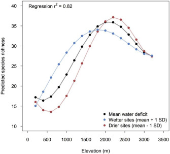

### 3.3. Beta diversity patterns

Beta diversity (i.e. dissimilarity in predicted species composition among grid cell pairs within elevation bands) decreased with increasing elevation (Fig. A2). Water deficit varies the most at low elevations (1000 m and below) in which species are less similar, and the least at high elevations (above 3200 m) where species composition is more similar. Beta diversity was positively related to annual water deficit, but started to decrease when water deficit values were greater than 200mm (Fig. A3), with the highest turnover occurring at elevations below 1000 m. A positive relationship was also shown between beta diversity and the variation of water deficit within elevation bands (Fig. 5). From a sample of 200 grid cells per 400 m elevational band, we find that species turnover is correlated with water deficit variation at low elevations, where water deficit variation is high (Fig. 5). However, species turnover is low when there is little variation in water deficit, as is the case at high elevations. These results may indicate that the species in this study occupy different niches along the water deficit gradient.

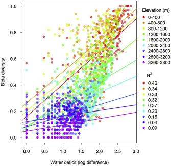

Fig. 5. The relationship between beta diversity and the variation in water deficit from a sample of 200 paired grid cells per 400 m elevation band (sample size selected for visual purposes). Water deficit varies the most at low elevations (1000 m and below) in which a species are less similar, and the least at high elevations (above 3200 m) with similar species.

### 3.4. Range size patterns

The average geographic range size of the 86 species for this study was over 11,000,000 km<sup>2</sup> while the median geographic range size was significantly smaller (4,008,403 km<sup>2</sup>), indicating that many of these species have small ranges. The geographic patterns of median range size show an unsurprising pattern for a [mountainous area](https://www.sciencedirect.com/topics/earth-and-planetary-sciences/mountainous-area): species with small or narrow ranges are common at mid-to high elevations and widespread species are common at low elevations (Fig. 6). In particular, grid cells with the smallest median ranges occurred in the Talamanca mountain range, which were the same grid cells with high species richness, while larger ranges and low species richness were more prevalent in the lowlands.

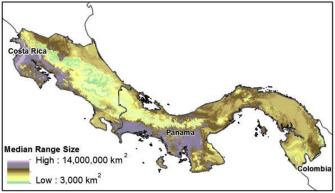

Fig. 6. Map of median range sizes. Range size for each species was calculated using the minimum convex polygon; median range size was determined based on all species predicted present for each grid cell.

## 4. Discussion

### 4.1. Species richness maps derived from stacked SDMs

We have shown that the stacked SDMs built in this study using the SRLI [fern](https://www.sciencedirect.com/topics/agricultural-and-biological-sciences/fern-ally) dataset can capture biogeographical patterns observed in both our field investigation and reported in the literature that could not be derived solely from the SRLI dataset alone. In particular, our analyses provide support for the usefulness of the stacked SDM approach in data-poor regions. Firstly, the mid-elevation peak in [species richness](https://www.sciencedirect.com/topics/earth-and-planetary-sciences/species-richness) predicted by the stacked SDM approach is consistent with previous Costa Rican studies based on fixed-area sampling plots along elevation gradients (Cardelus et al., 2006; Kluge et al., 2006; Watkins et al., 2006). These occurrence data do not by themselves produce accurate species richness patterns across the elevation gradient; yet we were able to build stacked SDMs with patterns that corroborate species richness patterns found in field transects (Tryon et al., 1989; Rahbek, 2005; Kessler et al., 2011b).

Secondly, we found relationships between species richness and water-energy variables that are consistent with previous studies at broad geographical scales (study extents > 800km; Hawkins et al., 2003) and regional geographical scales (elevational transects; Kessler et al., 2011b). Water-energy dynamics are widely accepted as having direct effects on plant diversity (O'Brien, 1993; Hawkins et al., 2003). In this study, water deficit and minimum temperature had clear relationships with species richness patterns and these variables have been shown to be biologically meaningful for ferns (Lehmann et al., 2002) and epiphytic plants (Cardelus et al., 2006), which are most of the species in our stacked SDMs.

A limitation of this method and its findings is that they do not provide information on the accuracy of associated species richness estimates. Validating such estimates is outside the scope of the current study and would involve combining both top-down macroecological modelling approaches and bottom-up [species distribution modelling](https://www.sciencedirect.com/topics/earth-and-planetary-sciences/environmental-niche-modeling) approaches (e.g. Calabrese et al., 2014). Comparisons of SDM results with our field data, however, and previous findings, lead us to expect that such studies will find the same qualitative pattern of species richness to that found here, although precise quantitative estimates will be different, although it should be noted that we cannot know how well the correspondence between stacked SDMs and field data will apply to other locations. For example, Pottier et al. (2013) found that varying species richness errors along an [environmental gradient](https://www.sciencedirect.com/topics/earth-and-planetary-sciences/environmental-gradient) could lead to different qualitative patterns of species richness being inferred from stacked SDMs than exist in nature.

### 4.2. Drivers of species richness and turnover along elevation gradients

The hump-backed relationship between species richness and elevation predicted by stacked-SDMs is consistent with several previous studies (Kromer et al., 2005) (Bhattarai et al., 2004; Kluge et al., 2006). The peak of the species richness coincides with the cloud condensation zone, where persistent fog maintains high relative humidity and protects ferns from excess irradiance, providing suitable habitat for many species intolerant of dryness (Page, 2002). The decline in species richness at higher elevations may well arise from a steady decline in air temperature with elevation (about 0.6 °C for every 100 m ascended), as argued by Kluge et al. (2006) working in Costa Rica, and mirroring the conclusions of Hawkins et al. (2003) based on latitudinal trends. Increased water deficit contributes to declines in species richness at lower altitude, alongside factors not measured in this study. The regression analysis shown in Fig. 4 and Fig. A4 indicates that greater water deficits have important influence on species richness at [lower altitude](https://www.sciencedirect.com/topics/earth-and-planetary-sciences/low-altitude). The models predict that differences in species richness between the wettest and driest sites found at 900 m altitude are almost as great as the difference between low elevation and 1800 m. It is particularly interesting to note that the peak in species richness descends down mountains in wetter regions; it is well known that the cloud zone descends to lower altitudes in wetter regions (Foster, 2001), and this is the most likely explanation for the observed pattern. There are concerns cloud zones will climb higher up mountainsides as a consequence of global warming, however, imperilling cloud forest specialists (Ponce-Reyes et al., 2012).

Water deficit differences do not appear sufficient to explain the marked drop off in species richness below about 500 m, for which we have no clear explanation. An analysis of the patterns and drivers of global fern species richness by Kreft et al. (2010) supports the notion that fern species richness is highest in regions with high [potential evapotranspiration](https://www.sciencedirect.com/topics/earth-and-planetary-sciences/potential-evapotranspiration), a high number of days with rainfall, as well as a high degree of topographic complexity. At the regional scale, previous studies have found that rainfall, humidity and topographic complexity are all important for fern occurrences in New Zealand (Lehmann et al., 2002) and Bolivia (Kessler, 2000). Other studies suggest that water and energy/temperature are correlated with elevational trends in species richness of [epiphytes](https://www.sciencedirect.com/topics/earth-and-planetary-sciences/epiphyte) (Kromer et al., 2005) and ferns in general (Kluge et al., 2006; Kessler et al., 2011b).

Beta diversity is often interpreted as a reflection of the degree of habitat specialization among species: high beta diversity is often associated with steep environmental gradients. High beta diversity in the lowlands is unsurprising given the strong water-deficit gradients at these altitudes, and given that a limited number of specialist ferns are adapted to xeric conditions (Hietz, 2010). Relatively low beta-diversity increasing at mid-elevations is harder to explain, given high species richness and many narrow-range species, both of which could result in high beta diversity. Alternatively, perhaps variation in composition has been reduced if multiple species with similar climatic tolerances were predicted in the same small high-elevation area, which would yield lower beta diversity.

Current-day climate does not provide a complete explanation for diversity patterns. The mid-domain effect (MDE) is an alternative explanation for the mid-elevation peak in species richness (Colwell and Hurtt, 1994). Glacial cycles may have contributed large changes to the composition of species assemblages as species ranges contracted and expanded, moving up and down elevation gradients. Hence diversity may have accumulated at elevations where the greatest species turnover occurred. An additional factor is colonization as Central America came into contact with North America about 10 million years ago and South America about 3 million years ago (Lieberman et al., 1996). It has been suggested that the colonization of Central America from the other continents is in fact still occurring. Hence it is possible that the Central American mountains are essentially geographically disjunct islands of suitable habitat that can be used to highlight rates of species immigration, given that montane environments are slower to penetrate than the lowlands (Lieberman et al., 1996).

This is perhaps due to the cloud zone occurring at mid-high elevations, offering more stable climatic conditions for species [co-existence](https://www.sciencedirect.com/topics/earth-and-planetary-sciences/coexistence), hence variation in species amongst areas at mid-elevations is lower than expected (see Horwath (2011)). The low beta diversity at high elevations may also reflect the lack of differences in the [microhabitats](https://www.sciencedirect.com/topics/earth-and-planetary-sciences/microhabitat) from the 1 km [spatial resolution](https://www.sciencedirect.com/topics/earth-and-planetary-sciences/spatial-resolution) of the environmental variables used in the distribution modelling. Almost half of the SRLI species have an epiphytic life form, whose distributions are known to be especially influenced by variation in microhabitat. A recent study suggests that species turnover is best explained by a complex interplay between dispersal limitations, climatic and habit requirements of species (Keil et al., 2012). Gaston and Blackburn (2000) suggest that the few comparable studies to draw general conclusions about large scale patterns in spatial turnover document inconsistent patterns; it is possible that the inconsistent patterns are due to interactions among these key factors.

### 4.3. Limitations of stacked SDMs

Collectively, this study suggests that biologically useful maps of species richness can be produced from stacked SDMs even when data are limited, allowing centres of high species richness to be identified in areas that have not been fully surveyed or are not accessible to collection. In particular, there is some evidence that our stacked SDMs failed to identify some areas within Darien National Park that are known to have high diversity. Darien NP is in the far eastern part of Panama, is a protected area and [UNESCO](https://www.sciencedirect.com/topics/earth-and-planetary-sciences/unesco) [World Heritage site](https://www.sciencedirect.com/topics/earth-and-planetary-sciences/world-heritage-site) and is one of only a few large forested areas remaining in Central America. The stacked SDMs predicted high richness in small [mountainous areas](https://www.sciencedirect.com/topics/earth-and-planetary-sciences/mountainous-area) within the park; while it is indeed known to be exceptionally biologically diverse, it seems likely that the models have under-estimated species richness in this region, probably because there is very little botanical information available (i.e. it is extremely data poor) (Prance, 2001).

The effectiveness of the stacked SDM approach in this study comes despite at least three limitations of the method: 1) that dispersal is typically not considered; 2) that there are no constraints on the maximum number of species that can co-occur in a geographic space; 3) and that biotic interactions are typically not included (Guisan and Rahbek, 2011). In the context of our study, these limitations are likely to lead to too many species being predicted in the same geographical unit (e.g. Graham and Hijmans, 2006; Pineda and Lobo, 2009; Dubuis et al., 2011; Mateo et al., 2012; Pellissier et al., 2012). This is probably why patterns from stacked SDMs predict shallower changes in relative species richness with elevation than were recorded in the field (Fig. 2b). Furthermore, range predictions can have high variability when fewer than 25 occurrences are available, which was the case for 46 of the 95 species in this study. However, this is a common situation with all but widespread species of least concern for conservation. Best practices to reduce model predictive variability were applied to construct the SDMs for this study, by correcting for sampling bias and using simple functional forms (Syfert et al., 2013), but it is inevitable that individual range maps were predicted with some degree of uncertainty and inaccuracy, especially with such small sample sizes. It is important to note that when the sample size is small, SDMs can identify regions with environmental conditions similar to where the species was found and so modelled distributions may not represent actual limits to the range of the species (Pearson et al., 2007). Nevertheless, our analyses provide evidence that the stacked SDM approach produces useful species richness maps, even in such data-poor regions.

That species richness estimates from stacked SDMs correspond to field data could have wide utility, both for producing new species richness maps and for informing field investigations. On the former, it is natural to question whether stacked SDMs produced using a global dataset can recapture large-scale patterns of species richness. Such an investigation might help expose [geographical regions](https://www.sciencedirect.com/topics/earth-and-planetary-sciences/geographical-region) for which species richness patterns from stacked SDMs do or do not correspond well to real patterns. On the latter, relative species richness estimates should be used alongside predicted range maps and recorded localities to help prioritise efforts and maximise value from field visits. Field visits to remote areas such as in this study are typically multi-purpose, combining studies of individual species, ecological mechanisms and macroecological patterns. Relative species richness maps may provide an additional source of information to help meet these multiple objectives.

## 5. Conclusion

Understanding the ecological processes that determine diversity patterns aids in the building of models that predict plant diversity in data-poor regions. Regions such as tropical Costa Rica and Panama, with steep [environmental gradients](https://www.sciencedirect.com/topics/earth-and-planetary-sciences/environmental-gradient), have the potential to help scientists better understand the processes behind global diversity patterns. In this study, stacked SDMs provide evidence of the importance of climatic influences on determining the mid-elevation peak in [species richness](https://www.sciencedirect.com/topics/earth-and-planetary-sciences/species-richness), in particular the influence of water availability and elevation, which leads to the natural next step of applying model inference about diversity patterns to other less well-known regions.

## Acknowledgements

[Fieldwork](https://www.sciencedirect.com/topics/earth-and-planetary-sciences/fieldwork) was made possible by a grant from the Natural History Museum, London (NHM). Field data collection was made possible with the help of Daniel Solano (INBio) and Elina Aletrari (Kings College, London). We are grateful to Harald Schneider (NHM and Xishuangbanna Tropical Botanic Garden, China) for guidance and assistance with [fern](https://www.sciencedirect.com/topics/agricultural-and-biological-sciences/fern-ally) identification. This work was supported by Microsoft Research awarded to DAC at Cambridge University, through its PhD Scholarship Programme.

## Appendix A. Supplementary data

The following is the supplementary data related to this article:[Download : Download XML file (248B)](https://ars.els-cdn.com/content/image/1-s2.0-S2351989418300921-mmc1.xml)

Online data.

## Appendix.

Table A1. Species used in the study, sorted by range size (measured as the minimum convex polygon), the SDM accuracy reported with a training AUC, the number of observations used to build the SDM.

| Species | Range size (km<sup>2</sup>) | Training AUC | Sample size |
| --- | --- | --- | --- |
| *Actinostachys pennula* | 10,230,360 | 0.9482 | 5 |
| *Adiantum decoratum* | 5,913,615 | 0.7672 | 56 |
| *Adiantum deflectens* | 11,922,530 | 0.9754 | 5 |
| *Adiantum lunulatum* | 120,969,533 | 0.7882 | 68 |
| *Adiantum terminatum* | 12,321,550 | 0.8369 | 16 |
| *Alsophila imrayana* | 4,008,403 | 0.7919 | 19 |
| *Anemia hirsuta* | 15,355,953 | 0.7647 | 45 |
| *Anemia oblongifolia* | 13,230,389 | 0.6957 | 53 |
| *Anemia phyllitidis* | 18,642,162 | 0.8543 | 110 |
| *Asplenium auriculatum* | 17,438,600 | 0.7934 | 140 |
| *Asplenium cristatum* | 16,252,163 | 0.832 | 66 |
| *Asplenium hastatum* | 7,975,684 | 0.9644 | 10 |
| *Asplenium lacerum* | 476,717 | 0.7819 | 72 |
| *Asplenium macilentum* | 5,742,193 | 0.7127 | 46 |
| *Asplenium polyphyllum* | 6,422,385 | 0.9619 | 53 |
| *Blotiella lindeniana* | 4,888,992 | 0.8857 | 42 |
| *Bolbitis pergamentacea* | 5,823,394 | 0.816 | 31 |
| *Botrychium underwoodianum* | 1,813,197 | 0.9292 | 11 |
| *Campyloneurum anetioides* | 11,532 | 0.9294 | 5 |
| *Campyloneurum xalapense* | 1,245,648 | 0.7414 | 35 |
| *Ceratopteris pteridoides* | 15,788,232 | 0.7409 | 25 |
| *Cnemidaria cocleana* | 104,706 | 0.896 | 40 |
| *Cnemidaria varians* | 20,737 | 0.7536 | 8 |
| *Ctenitis chiriquiana* | 2195 | 0.8973 | 5 |
| *Ctenitis refulgens* | 6,050,684 | 0.913 | 10 |
| *Cyathea williamsii* | 1,099,163 | 0.9479 | 26 |
| *Danaea wendlandii* | 784,113 | 0.8596 | 67 |
| *Dennstaedtia bipinnata* | 9,496,344 | 0.6933 | 69 |
| *Diplazium franconis* | 847,804 | 0.869 | 13 |
| *Diplazium grandifolium* | 10,935,504 | 0.741 | 73 |

[output cut: 56 more lines]

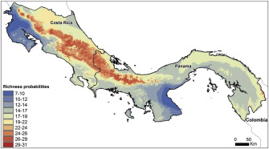

Fig. A1. [Species Richness](https://www.sciencedirect.com/topics/earth-and-planetary-sciences/species-richness) estimated by stacking SDMs derived from Maxent suitability of occurrence maps.

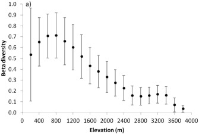

Fig. A2. The relationship between beta diversity among grid cells, predicted from species distribution models, and elevation. Beta diversity (Jaccard's dissimilarity of cells within each 200 m elevation band) decreases as elevation increases. Error bars are standard deviations.

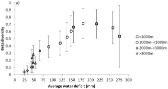

Fig. A3. The relationship between beta diversity and water deficit with elevation bands. The elevation bands are divided into four classes, as shown by Beta diversity the symbol. Error bars are standard deviations.

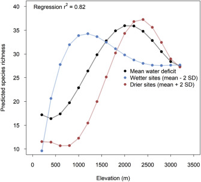

Fig. A4. Predicted variation in species richness with elevation and water deficit, based on linear regression modelling. The black curve indicates the elevational trend for sites with average water deficit (as calculated for each altitude band). The blue curve indicates the elevational trend for wetter sites, with below-average water deficits (i.e. mean – 2 standard deviations of the distribution, calculated for each altitude band). The red curve indicates the elevational trend for drier sites, with above-average water deficits (i.e. mean + 2 standard deviations of the distribution, calculated for each altitude band). The figure is drawn in Fig. 4 with mean ± 1 standard deviation.

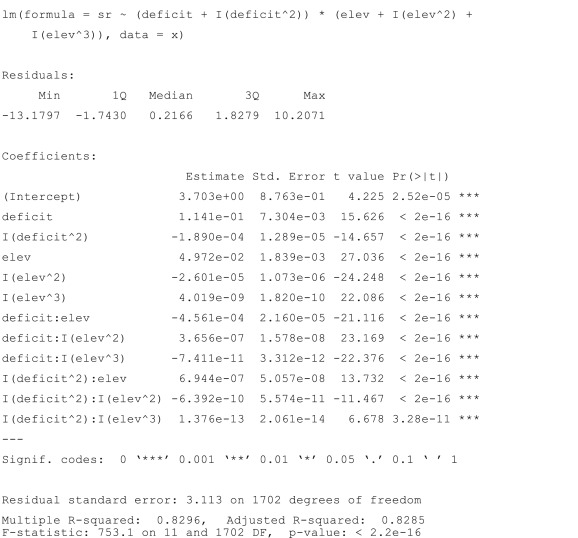

Fig. A5. Results of a linear regression modelling (using the *lm* function of *R*) of predicted species richness (*sr*) as a function of water deficit (*deficit*) and elevation (*elev*).

## Research data for this article

Data not available / Data will be made available on request

[About research data](https://www.elsevier.com/authors/author-services/research-data)

## References

**Anderson et al., 2011**

M.J. Anderson, T.O. Crist, J.M. Chase, M. Vellend, B.D. Inouye, A.L. Freestone, N.J. Sanders, H.V. Cornell, L.S. Comita, K.F. Davies, S.P. Harrison, N.J.B. Kraft, J.C. Stegen, N.G. Swenson**Navigating the multiple meanings of β diversity: a roadmap for the practicing ecologist**

Ecol. Lett., 14 (2011), pp. 19-28

[CrossRef](https://doi.org/10.1111/j.1461-0248.2010.01552.x)[View Record in Scopus](https://www.scopus.com/inward/record.url?eid=2-s2.0-78650061319&partnerID=10&rel=R3.0.0)[Google Scholar](https://scholar.google.com/scholar?q=Navigating%20the%20multiple%20meanings%20of%20%20diversity:%20a%20roadmap%20for%20the%20practicing%20ecologist)

**Austin, 2002**

M.P. Austin**Spatial prediction of species distribution: an interface between ecological theory and statistical modelling**

Ecol. Model., 157 (2002), pp. 101-118

[Article](https://www.sciencedirect.com/science/article/pii/S0304380002002053)[Download PDF](https://www.sciencedirect.com/science/article/pii/S0304380002002053/pdfft?md5=86e234d10027be96b145a234b47113f6&pid=1-s2.0-S0304380002002053-main.pdf)[View Record in Scopus](https://www.scopus.com/inward/record.url?eid=2-s2.0-0037202447&partnerID=10&rel=R3.0.0)Google Scholar

**Baillie et al., 2008**

J.E.M. Baillie, B. Collen, R. Amin, H.R. Akcakaya, S.H.M. Butchart, N. Brummitt, T.R. Meagher, M. Ram, C. Hilton-Taylor, G.M. Mace**Toward monitoring global biodiversity**

Conserv. Lett., 1 (2008), pp. 18-26

[View Record in Scopus](https://www.scopus.com/inward/record.url?eid=2-s2.0-57449101206&partnerID=10&rel=R3.0.0)Google Scholar

**Baselga and Orme, 2012**

A. Baselga, C.D.L. Orme**betapart: an R package for the study of beta diversity**

Meth. Ecol. Evol., 3 (2012), pp. 808-812

[View Record in Scopus](https://www.scopus.com/inward/record.url?eid=2-s2.0-84874199777&partnerID=10&rel=R3.0.0)[Google Scholar](https://scholar.google.com/scholar_lookup?title=betapart%3A%20an%20R%20package%20for%20the%20study%20of%20beta%20diversity&publication_year=2012&author=A.%20Baselga&author=C.D.L.%20Orme)

**Bhattarai et al., 2004**

K.R. Bhattarai, O.R. Vetaas, J.A. Grytnes**Fern species richness along a central Himalayan elevational gradient, Nepal**

J. Biogeogr., 31 (2004), pp. 389-400

[CrossRef](https://doi.org/10.1046/j.0305-0270.2003.01013.x)[View Record in Scopus](https://www.scopus.com/inward/record.url?eid=2-s2.0-1542319942&partnerID=10&rel=R3.0.0)Google Scholar

**Brummitt et al., 2016**

N. Brummitt, E. Aletrari, M.M. Syfert, M. Mulligan**Where are threatened ferns found?**

Global Conserv. Priorities pteridophytes, 54 (2016), p. 616

[View Record in Scopus](https://www.scopus.com/inward/record.url?eid=2-s2.0-85059127929&partnerID=10&rel=R3.0.0)[Google Scholar](https://scholar.google.com/scholar?q=Where%20are%20threatened%20ferns%20found)

**Brummitt et al., 2015a**

N. Brummitt, S.P. Bachman, E. Aletrari, H. Chadburn, J. Griffiths-Lee, M. Lutz, J. Moat, M.C. Rivers, M.M. Syfert, E.M. Nic Lughadha**The sampled Red List Index for plants, phase II: ground-truthing specimen-based conservation assessments**

Philos. Trans. R. Soc. Lond. B Biol. Sci., 370 (2015), Article 20140015

[CrossRef](https://doi.org/10.1098/rstb.2014.0015)Google Scholar

**Brummitt et al., 2015b**

N.A. Brummitt, S.P. Bachman, J. Griffiths-Lee, M. Lutz, J.F. Moat, A. Farjon, J.S. Donaldson, C. Hilton-Taylor, T.R. Meagher, S. Albuquerque, E. Aletrari, A.K. Andrews, G. Atchison, E. Baloch, B. Barlozzini, A. Brunazzi, J. Carretero, M. Celesti, H. Chadburn, E. Cianfoni, C. Cockel, V. Coldwell, B. Concetti, S. Contu, V. Crook, P. Dyson, L. Gardiner, N. Ghanim, H. Greene, A. Groom, R. Harker, D. Hopkins, S. Khela, P. Lakeman-Fraser, H. Lindon, H. Lockwood, C. Loftus, D. Lombrici, L. Lopez-Poveda, J. Lyon, P. Malcolm-Tompkins, K. McGregor, L. Moreno, L. Murray, K. Nazar, E. Power, M. Quiton Tuijtelaars, R. Salter, R. Segrott, H. Thacker, L.J. Thomas, S. Tingvoll, G. Watkinson, K. Wojtaszekova, E.M. Nic Lughadha**Green plants in the red: a baseline global assessment for the IUCN sampled red list index for plants**

PLoS One, 10 (2015), Article e0135152

[CrossRef](https://doi.org/10.1371/journal.pone.0135152)[View Record in Scopus](https://www.scopus.com/inward/record.url?eid=2-s2.0-84942155620&partnerID=10&rel=R3.0.0)Google Scholar

**Brummitt et al., 2008**

N.A. Brummitt, S.P. Bachman, J. Moat**Applications of the IUCN Red List: towards a global barometer for plant diversity**

Endanger. Species Res., 6 (2008), pp. 127-135

[View Record in Scopus](https://www.scopus.com/inward/record.url?eid=2-s2.0-65349111882&partnerID=10&rel=R3.0.0)Google Scholar

**Burgman and Fox, 2003**

M.A. Burgman, J.C. Fox**Bias in species range estimates from minimum convex polygons: implications for conservation and options for improved planning**

Anim. Conserv., 6 (2003), pp. 19-28

[CrossRef](https://doi.org/10.1017/S1367943003003044)[View Record in Scopus](https://www.scopus.com/inward/record.url?eid=2-s2.0-3042538066&partnerID=10&rel=R3.0.0)Google Scholar

**Calabrese et al., 2014**

J.M. Calabrese, G. Certain, C. Kraan, C.F. Dormann**Stacking species distribution models and adjusting bias by linking them to macroecological models**

Global Ecol. Biogeogr., 23 (2014), pp. 99-112

[CrossRef](https://doi.org/10.1111/geb.12102)[View Record in Scopus](https://www.scopus.com/inward/record.url?eid=2-s2.0-84896124501&partnerID=10&rel=R3.0.0)Google Scholar

**Callmander et al., 2007**

M.W. Callmander, G.E. Schatz, P.P. Lowry II, M.O. Laivao, J. Raharimampionona, S. Andriambololonera, T. Raminosoa, T.K. Consiglio**Identification of priority areas for plant conservation in Madagascar using Red List criteria: rare and threatened Pandanaceae indicate sites in need of protection**

Oryx, 41 (2007), pp. 168-176

[View Record in Scopus](https://www.scopus.com/inward/record.url?eid=2-s2.0-34547451094&partnerID=10&rel=R3.0.0)Google Scholar

**Cardelus et al., 2006**

C.L. Cardelus, R.K. Colwell, J.E. Watkins**Vascular epiphyte distribution patterns: explaining the mid-elevation richness peak**

J. Ecol., 94 (2006), pp. 144-156

[CrossRef](https://doi.org/10.1111/j.1365-2745.2005.01052.x)[View Record in Scopus](https://www.scopus.com/inward/record.url?eid=2-s2.0-31944447136&partnerID=10&rel=R3.0.0)Google Scholar

**Cao et al., 2013**

Y. Cao, R.E. DeWalt, J.L. Robinson, T. Tweddale, L. Hinz, M. Pessino**Using Maxent to model the historic distributions of stonefly species in Illinois streams: the effects of regularization and threshold selections**

Ecol. Model., 259 (2013), pp. 30-39

[Article](https://www.sciencedirect.com/science/article/pii/S0304380013001695)[Download PDF](https://www.sciencedirect.com/science/article/pii/S0304380013001695/pdfft?md5=c8b7b1cceee7a35c75a5e9ece7219ab6&pid=1-s2.0-S0304380013001695-main.pdf)[CrossRef](https://doi.org/10.3901/JME.2013.18.030)[View Record in Scopus](https://www.scopus.com/inward/record.url?eid=2-s2.0-84876790334&partnerID=10&rel=R3.0.0)Google Scholar

**Collen et al., 2008**

B. Collen, M. Ram, T. Zamin, L. McRae**The tropical biodiversity data gap: addressing disparity in global monitoring**

Trop. Conserv. Sci., 1 (2008), pp. 75-88

[CrossRef](https://doi.org/10.1177/194008290800100202)[View Record in Scopus](https://www.scopus.com/inward/record.url?eid=2-s2.0-67349237975&partnerID=10&rel=R3.0.0)Google Scholar

**Colwell and Hurtt, 1994**

R.K. Colwell, G.C. Hurtt**Non-biological gradients in species richness and a spurious Rapoport effect**

Am. Nat., 144 (1994), pp. 570-595

[View Record in Scopus](https://www.scopus.com/inward/record.url?eid=2-s2.0-0028163949&partnerID=10&rel=R3.0.0)[Google Scholar](https://scholar.google.com/scholar_lookup?title=Non-biological%20gradients%20in%20species%20richness%20and%20a%20spurious%20Rapoport%20effect&publication_year=1994&author=R.K.%20Colwell&author=G.C.%20Hurtt)

**Cord et al., 2014**

A.F. Cord, D. Klein, D.S. Gernandt, J.A.P. la Rosa, S. Dech**Remote sensing data can improve predictions of species richness by stacked species distribution models: a case study for Mexican pines**

J. Biogeogr., 41 (2014), pp. 736-748

[CrossRef](https://doi.org/10.1111/jbi.12225)[View Record in Scopus](https://www.scopus.com/inward/record.url?eid=2-s2.0-84896110415&partnerID=10&rel=R3.0.0)Google Scholar

**D'Amen et al., 2017**

M. D'Amen, C. Rahbek, N.E. Zimmermann, A. Guisan**Spatial predictions at the community level: from current approaches to future frameworks**

Biol. Rev., 92 (2017), pp. 169-187

[CrossRef](https://doi.org/10.1111/brv.12222)[View Record in Scopus](https://www.scopus.com/inward/record.url?eid=2-s2.0-84945965058&partnerID=10&rel=R3.0.0)Google Scholar

**DeFries et al., 2005**

R. DeFries, A. Hansen, A.C. Newton, M.C. Hansen**Increasing isolation of protected areas in tropical forests over the past twenty years**

Ecol. Appl., 15 (2005), pp. 19-26

[CrossRef](https://doi.org/10.1890/03-5258)[View Record in Scopus](https://www.scopus.com/inward/record.url?eid=2-s2.0-13944263687&partnerID=10&rel=R3.0.0)Google Scholar

**Distler et al., 2015**

T. Distler, J.G. Schuetz, J. Velásquez-Tibatá, G.M. Langham, R. Ladle**Stacked species distribution models and macroecological models provide congruent projections of avian species richness under climate change**

J. Biogeogr., 42 (2015), pp. 976-988

[CrossRef](https://doi.org/10.1111/jbi.12479)[View Record in Scopus](https://www.scopus.com/inward/record.url?eid=2-s2.0-84926518687&partnerID=10&rel=R3.0.0)Google Scholar

**Dubuis et al., 2011**

A. Dubuis, J. Pottier, V. Rion, L. Pellissier, J.P. Theurillat, A. Guisan**Predicting spatial patterns of plant species richness: a comparison of direct macroecological and species stacking modelling approaches**

Divers. Distrib., 17 (2011), pp. 1122-1131

[CrossRef](https://doi.org/10.1111/j.1472-4642.2011.00792.x)[View Record in Scopus](https://www.scopus.com/inward/record.url?eid=2-s2.0-80054094311&partnerID=10&rel=R3.0.0)Google Scholar

**Elith et al., 2006**

J. Elith, C.H. Graham, R.P. Anderson, M. Dudik, S. Ferrier, A. Guisan, R.J. Hijmans, F. Huettmann, J.R. Leathwick, A. Lehmann, J. Li, L.G. Lohmann, B.A. Loiselle, G. Manion, C. Moritz, M. Nakamura, Y. Nakazawa, J.M. Overton, A.T. Peterson, S.J. Phillips, K. Richardson, R. Scachetti-Pereira, R.E. Schapire, J. Soberon, S. Williams, M.S. Wisz, N.E. Zimmermann**Novel methods improve prediction of species' distributions from occurrence data**

Ecography, 29 (2006), pp. 129-151

[CrossRef](https://doi.org/10.1111/j.2006.0906-7590.04596.x)[View Record in Scopus](https://www.scopus.com/inward/record.url?eid=2-s2.0-33645917058&partnerID=10&rel=R3.0.0)[Google Scholar](https://scholar.google.com/scholar?q=Novel%20methods%20improve%20prediction%20of%20species%20distributions%20from%20occurrence%20data)

**Elith and Leathwick, 2009**

J. Elith, J.R. Leathwick**Species distribution models: ecological explanation and prediction across space and time**

Annu. Rev. Ecol. Evol. Systemat., 40 (2009), pp. 677-697

[CrossRef](https://doi.org/10.1146/annurev.ecolsys.110308.120159)[View Record in Scopus](https://www.scopus.com/inward/record.url?eid=2-s2.0-73949141293&partnerID=10&rel=R3.0.0)Google Scholar

**Elith et al., 2011**

J. Elith, S.J. Phillips, T. Hastie, M. Dudik, Y.E. Chee, C.J. Yates**A statistical explanation of MaxEnt for ecologists**

Divers. Distrib., 17 (2011), pp. 43-57

[CrossRef](https://doi.org/10.1111/j.1472-4642.2010.00725.x)[View Record in Scopus](https://www.scopus.com/inward/record.url?eid=2-s2.0-78649991963&partnerID=10&rel=R3.0.0)Google Scholar

**Engler et al., 2011**

R. Engler, C.F. Randin, W. Thuiller, S. Dullinger, N.E. Zimmermann, M.B. Araujo, P.B. Pearman, G. Le Lay, C. Piedallu, C.H. Albert, P. Choler, G. Coldea, X. De Lamo, T. Dirnbock, J.C. Gegout, D. Gomez-Garcia, J.A. Grytnes, E. Heegaard, F. Hoistad, D. Nogues-Bravo, S. Normand, M. Puscas, M.T. Sebastia, A. Stanisci, J.P. Theurillat, M.R. Trivedi, P. Vittoz, A. Guisan**21st century climate change threatens mountain flora unequally across Europe**

Global Change Biol., 17 (2011), pp. 2330-2341

[CrossRef](https://doi.org/10.1111/j.1365-2486.2010.02393.x)[View Record in Scopus](https://www.scopus.com/inward/record.url?eid=2-s2.0-79957814431&partnerID=10&rel=R3.0.0)Google Scholar

**Engler et al., 2009**

R. Engler, C.F. Randin, P. Vittoz, T. Czaka, M. Beniston, N.E. Zimmermann, A. Guisan**Predicting future distributions of mountain plants under climate change: does dispersal capacity matter?**

Ecography, 32 (2009), pp. 34-45

[CrossRef](https://doi.org/10.1111/j.1600-0587.2009.05789.x)[View Record in Scopus](https://www.scopus.com/inward/record.url?eid=2-s2.0-63849107800&partnerID=10&rel=R3.0.0)[Google Scholar](https://scholar.google.com/scholar?q=Predicting%20future%20distributions%20of%20mountain%20plants%20under%20climate%20change:%20does%20dispersal%20capacity%20matter)

**Ferrier and Guisan, 2006**

S. Ferrier, A. Guisan**Spatial modelling of biodiversity at the community level**

Ecology, 43 (2006), pp. 393-404

[CrossRef](https://doi.org/10.1111/j.1365-2664.2006.01149.x)[View Record in Scopus](https://www.scopus.com/inward/record.url?eid=2-s2.0-33646556408&partnerID=10&rel=R3.0.0)[Google Scholar](https://scholar.google.com/scholar_lookup?title=Spatial%20modelling%20of%20biodiversity%20at%20the%20community%20level&publication_year=2006&author=S.%20Ferrier&author=A.%20Guisan)

**Fielding and Bell, 1997**

A.H. Fielding, J.F. Bell**A review of methods for the assessment of prediction errors in conservation presence/absence models**

Environ. Conserv., 24 (1997), pp. 38-49

[View Record in Scopus](https://www.scopus.com/inward/record.url?eid=2-s2.0-0030953391&partnerID=10&rel=R3.0.0)[Google Scholar](https://scholar.google.com/scholar?q=A%C2%A0review%20of%20methods%20for%20the%20assessment%20of%20prediction%20errors%20in%20conservation%20presenceabsence%20models)

**Foster, 2001**

P. Foster**The potential negative impacts of global climate change on tropical montane cloud forests**

Earth Sci. Rev., 55 (1–2) (2001), pp. 73-106

[Article](https://www.sciencedirect.com/science/article/pii/S0012825201000563)[Download PDF](https://www.sciencedirect.com/science/article/pii/S0012825201000563/pdfft?md5=85c0f2689d9bd93990601018026335b1&pid=1-s2.0-S0012825201000563-main.pdf)[View Record in Scopus](https://www.scopus.com/inward/record.url?eid=2-s2.0-0035167462&partnerID=10&rel=R3.0.0)[Google Scholar](https://scholar.google.com/scholar_lookup?title=The%20potential%20negative%20impacts%20of%20global%20climate%20change%20on%20tropical%20montane%20cloud%20forests&publication_year=2001&author=P.%20Foster)

**Franklin, 2009**

J. Franklin**Mapping Species Distributions: Spatial Inference and Prediction**

Cambridge University Press, Cambridge, UK (2009)

[Google Scholar](https://scholar.google.com/scholar_lookup?title=Mapping%20Species%20Distributions%3A%20Spatial%20Inference%20and%20Prediction&publication_year=2009&author=J.%20Franklin)

**Gaston, 1991**

K.J. Gaston**How large is a species' geographic range?**

Oikos, 61 (1991), pp. 434-438

[CrossRef](https://doi.org/10.2307/3545251)[Google Scholar](https://scholar.google.com/scholar?q=How%20large%20is%20a%20species%20geographic%20range)

**Gaston and Blackburn, 2000**

K.J. Gaston, T.M. Blackburn**Pattern and Process in Macroecology**

Blackwell Science, Oxford (2000)

[Google Scholar](https://scholar.google.com/scholar_lookup?title=Pattern%20and%20Process%20in%20Macroecology&publication_year=2000&author=K.J.%20Gaston&author=T.M.%20Blackburn)

**Gaston and Fuller, 2009**

K.J. Gaston, R.A. Fuller**The sizes of species' geographic ranges**

J. Appl. Ecol., 46 (2009), pp. 1-9

[CrossRef](https://doi.org/10.1111/j.1365-2664.2008.01596.x)[View Record in Scopus](https://www.scopus.com/inward/record.url?eid=2-s2.0-58249107946&partnerID=10&rel=R3.0.0)[Google Scholar](https://scholar.google.com/scholar?q=The%20sizes%20of%20species%20geographic%20ranges)

**Gentry and Dodson, 1987**

A.H. Gentry, C.H. Dodson**Diversity and biogeography of neotropical vascular epiphytes**

Ann. Mo. Bot. Gard., 74 (1987), p. 233

[Google Scholar](https://scholar.google.com/scholar_lookup?title=Diversity%20and%20biogeography%20of%20neotropical%20vascular%20epiphytes&publication_year=1987&author=A.H.%20Gentry&author=C.H.%20Dodson)

**Graham and Hijmans, 2006**

C.H. Graham, R.J. Hijmans**A comparison of methods for mapping species ranges and species richness**

Global Ecol. Biogeogr., 15 (2006), pp. 578-587

[CrossRef](https://doi.org/10.1111/j.1466-8238.2006.00257.x)[View Record in Scopus](https://www.scopus.com/inward/record.url?eid=2-s2.0-33750348546&partnerID=10&rel=R3.0.0)[Google Scholar](https://scholar.google.com/scholar_lookup?title=A%C2%A0comparison%20of%20methods%20for%20mapping%20species%20ranges%20and%20species%20richness&publication_year=2006&author=C.H.%20Graham&author=R.J.%20Hijmans)

**Guisan and Rahbek, 2011**

A. Guisan, C. Rahbek**SESAM - a new framework integrating macroecological and species distribution models for predicting spatio-temporal patterns of species assemblages**

J. Biogeogr., 38 (2011), pp. 1433-1444

[CrossRef](https://doi.org/10.1111/j.1365-2699.2011.02550.x)[View Record in Scopus](https://www.scopus.com/inward/record.url?eid=2-s2.0-79960275810&partnerID=10&rel=R3.0.0)Google Scholar

**Hastenrath, 1967**

S.L. Hastenrath**Lake-level changes and climatic fluctuations in central America**

J. Trop. Geogr., 25 (1967), pp. 24-33

[View Record in Scopus](https://www.scopus.com/inward/record.url?eid=2-s2.0-84876309856&partnerID=10&rel=R3.0.0)[Google Scholar](https://scholar.google.com/scholar_lookup?title=Lake-level%20changes%20and%20climatic%20fluctuations%20in%20central%20America&publication_year=1967&author=S.L.%20Hastenrath)

**Hawkins et al., 2003**

B.A. Hawkins, R. Field, H.V. Cornell, D.J. Currie, J.F. Guegan, D.M. Kaufman, J.T. Kerr, G.G. Mittelbach, T. Oberdorff, E.M. O'Brien, E.E. Porter, J.R.G. Turner**Energy, water, and broad-scale geographic patterns of species richness**

Ecology, 84 (2003), pp. 3105-3117

[CrossRef](https://doi.org/10.1890/03-8006)[View Record in Scopus](https://www.scopus.com/inward/record.url?eid=2-s2.0-10744225171&partnerID=10&rel=R3.0.0)Google Scholar

**Hernandez et al., 2006**

P.A. Hernandez, C.H. Graham, L.L. Master, D.L. Albert**The effect of sample size and species characteristics on performance of different species distribution modeling methods**

Ecography, 29 (2006), pp. 773-785

[CrossRef](https://doi.org/10.1111/j.0906-7590.2006.04700.x)[View Record in Scopus](https://www.scopus.com/inward/record.url?eid=2-s2.0-33750352002&partnerID=10&rel=R3.0.0)Google Scholar

**Hietz, 2010**

P. Hietz**Fern adaptations to xeric environments**

K. Mehltreter, L.R. Walker, J.M. Sharpe (Eds.), *Fern Ecology*, Chapter, Cambridge University Press, Cambridge (2010), pp. 140-176

[CrossRef](https://doi.org/10.1017/CBO9780511844898.006)[View Record in Scopus](https://www.scopus.com/inward/record.url?eid=2-s2.0-84892761601&partnerID=10&rel=R3.0.0)[Google Scholar](https://scholar.google.com/scholar_lookup?title=Fern%20adaptations%20to%20xeric%20environments&publication_year=2010&author=P.%20Hietz)

**Hijmans et al., 2005**

R.J. Hijmans, S.E. Cameron, J.L. Parra, P.G. Jones, A. Jarvis**Very high resolution interpolated climate surfaces for global land areas**

Int. J. Climatol., 25 (2005), pp. 1965-1978

[CrossRef](https://doi.org/10.1002/joc.1276)[View Record in Scopus](https://www.scopus.com/inward/record.url?eid=2-s2.0-29544443445&partnerID=10&rel=R3.0.0)Google Scholar

**Horwath, 2011**

A. Horwath**Epiphytic Bryophytes as Cloud Forest Indicators: Stable Isotopes, Biomass and Diversity along an Altitudinal Gradient in Peru**

Plant Sciences. University of Cambridge, Cambridge, UK (2011), p. 284

Google Scholar

**Joppa et al., 2008**

L.N. Joppa, S.R. Loarie, S.L. Pimm**On the protection of "protected areas**

Proc. Natl. Acad. Sci. U.S.A., 105 (2008), pp. 6673-6678

[CrossRef](https://doi.org/10.1073/pnas.0802471105)[View Record in Scopus](https://www.scopus.com/inward/record.url?eid=2-s2.0-44349166177&partnerID=10&rel=R3.0.0)[Google Scholar](https://scholar.google.com/scholar?q=On%20the%20protection%20of%20protected%20areas)

**Keil et al., 2012**

P. Keil, O. Schweiger, I. Kuhn, W.E. Kunin, M. Kuussaari, J. Settele, K. Henle, L. Brotons, G. Pe'er, S. Lengyel, A. Moustakas, H. Steinicke, D. Storch**Patterns of beta diversity in Europe: the role of climate, land cover and distance across scales**

J. Biogeogr., 39 (2012), pp. 1473-1486

[CrossRef](https://doi.org/10.1111/j.1365-2699.2012.02701.x)[View Record in Scopus](https://www.scopus.com/inward/record.url?eid=2-s2.0-84864023618&partnerID=10&rel=R3.0.0)Google Scholar

**Kessler, 2000**

M. Kessler**Elevational gradients in species richness and endemism of selected plant groups in the central Bolivian Andes**

Plant Ecol., 149 (2000), pp. 181-193

[View Record in Scopus](https://www.scopus.com/inward/record.url?eid=2-s2.0-0034489189&partnerID=10&rel=R3.0.0)Google Scholar

**Kessler et al., 2011a**

M. Kessler, J.-A. Grytnes, S.R.P. Halloy, J. Kluge, T. Krömer, B. León, M.J. Macía, K.R. Young**Gradients of plant diversity: local patterns and processes**

S.K. Herzog, R. Martínez, P.M. Jørgensen, H. Tiessen (Eds.), Climate Change and Biodiversity in the Tropical Andes, IAI-SCOPE, São José dos Campos, Brazil (2011), pp. 204-219

[View Record in Scopus](https://www.scopus.com/inward/record.url?eid=2-s2.0-84913588258&partnerID=10&rel=R3.0.0)Google Scholar

**Kessler et al., 2011b**

M. Kessler, J. Kluge, A. Hemp, R. Ohlemuller**A global comparative analysis of elevational species richness patterns of ferns**

Global Ecol. Biogeogr., 20 (2011), pp. 868-880

[CrossRef](https://doi.org/10.1111/j.1466-8238.2011.00653.x)[View Record in Scopus](https://www.scopus.com/inward/record.url?eid=2-s2.0-80053653801&partnerID=10&rel=R3.0.0)Google Scholar

**Kluge et al., 2006**

J. Kluge, M. Kessler, R.R. Dunn**What drives elevational patterns of diversity? A test of geometric constraints, climate and species pool effects for pteridophytes on an elevational gradient in Costa Rica**

Global Ecol. Biogeogr., 15 (2006), pp. 358-371

[View Record in Scopus](https://www.scopus.com/inward/record.url?eid=2-s2.0-33745620438&partnerID=10&rel=R3.0.0)Google Scholar

**Koleff et al., 2003a**

P. Koleff, K.J. Gaston, J.J. Lennon**Measuring beta diversity for presence-absence data**

J. Anim. Ecol., 72 (2003), pp. 367-382

[View Record in Scopus](https://www.scopus.com/inward/record.url?eid=2-s2.0-0038670419&partnerID=10&rel=R3.0.0)[Google Scholar](https://scholar.google.com/scholar_lookup?title=Measuring%20beta%20diversity%20for%20presence-absence%20data&publication_year=2003&author=P.%20Koleff&author=K.J.%20Gaston&author=J.J.%20Lennon)

**Koleff et al., 2003b**

P. Koleff, J.J. Lennon, K.J. Gaston**Are there latitudinal gradients in species turnover?**

Global Ecol. Biogeogr., 12 (2003), pp. 483-498

[View Record in Scopus](https://www.scopus.com/inward/record.url?eid=2-s2.0-0242626720&partnerID=10&rel=R3.0.0)[Google Scholar](https://scholar.google.com/scholar?q=Are%20there%20latitudinal%20gradients%20in%20species%20turnover)

**Kreft et al., 2010**

H. Kreft, W. Jetz, J. Mutke, W. Barthlott**Contrasting environmental and regional effects on global pteridophyte and seed plant diversity**

Ecography, 33 (2010), pp. 408-419

[CrossRef](https://doi.org/10.1111/j.1600-0587.2010.06434.x)[View Record in Scopus](https://www.scopus.com/inward/record.url?eid=2-s2.0-78651262782&partnerID=10&rel=R3.0.0)Google Scholar

**Kromer et al., 2005**

T. Kromer, M. Kessler, S.R. Gradstein, A. Acebey**Diversity patterns of vascular epiphytes along an elevational gradient in the Andes**

J. Biogeogr., 32 (2005), pp. 1799-1809

[CrossRef](https://doi.org/10.1111/j.1365-2699.2005.01318.x)[View Record in Scopus](https://www.scopus.com/inward/record.url?eid=2-s2.0-33644960285&partnerID=10&rel=R3.0.0)Google Scholar

**Lehmann et al., 2002**

A. Lehmann, J.R. Leathwick, J.M. Overton**Assessing New Zealand fern diversity from spatial predictions of species assemblages**

Biodivers. Conserv., 11 (2002), pp. 2217-2238

[View Record in Scopus](https://www.scopus.com/inward/record.url?eid=2-s2.0-0036933905&partnerID=10&rel=R3.0.0)Google Scholar

**Lieberman et al., 1996**

D. Lieberman, M. Lieberman, R. Peralta, G.S. Hartshorn**Tropical forest structure and composition on a large-scale altitudinal gradient in Costa Rica**

J. Ecol., 84 (1996), pp. 137-152

[CrossRef](https://doi.org/10.2307/2261350)[View Record in Scopus](https://www.scopus.com/inward/record.url?eid=2-s2.0-0029769237&partnerID=10&rel=R3.0.0)Google Scholar

**Liu et al., 2005**

C. Liu, P.M. Berry, T.P. Dawson, R.G. Pearson**Selecting thresholds of occurrence in the prediction of species distributions**

Ecography, 28 (2005), pp. 385-393

[CrossRef](https://doi.org/10.1111/j.0906-7590.2005.03957.x)[View Record in Scopus](https://www.scopus.com/inward/record.url?eid=2-s2.0-20444488428&partnerID=10&rel=R3.0.0)Google Scholar

**Liu et al., 2013**

C. Liu, M. White, G. Newell**Selecting thresholds for the prediction of species occurrence with presence-only data**

J. Biogeogr., 40 (2013), pp. 778-789

[CrossRef](https://doi.org/10.1111/jbi.12058)[View Record in Scopus](https://www.scopus.com/inward/record.url?eid=2-s2.0-84875074028&partnerID=10&rel=R3.0.0)Google Scholar

**Mateo et al., 2016**

R.G. Mateo, O. Broennimann, S. Normand, B. Petitpierre, M.B. Araújo, J.-C. Svenning, A. Baselga, F. Fernández-González, V. Gómez-Rubio, J. Muñoz, G.M. Suarez, M. Luoto, A. Guisan, A. Vanderpoorten**The mossy north: an inverse latitudinal diversity gradient in European bryophytes**

Sci. Rep., 6 (2016), p. 25546

[View Record in Scopus](https://www.scopus.com/inward/record.url?eid=2-s2.0-84966925865&partnerID=10&rel=R3.0.0)Google Scholar

**Mateo et al., 2012**

R.G. Mateo, A.M. Felicisimo, J. Pottier, A. Guisan, J. Munoz**Do stacked species distribution models reflect altitudinal diversity patterns?**

PLoS One, 7 (3) (2012), Article e32586

[CrossRef](https://doi.org/10.1371/journal.pone.0032586)[View Record in Scopus](https://www.scopus.com/inward/record.url?eid=2-s2.0-84857721354&partnerID=10&rel=R3.0.0)[Google Scholar](https://scholar.google.com/scholar?q=Do%20stacked%20species%20distribution%20models%20reflect%20altitudinal%20diversity%20patterns)

**Mateo et al., 2017**

R.G. Mateo, K. Mokany, A. Guisan**Biodiversity models: what if unsaturation is the rule?**

Trends Ecol. Evol., 32 (2017), pp. 556-566

[Article](https://www.sciencedirect.com/science/article/pii/S0169534717301283)[Download PDF](https://www.sciencedirect.com/science/article/pii/S0169534717301283/pdfft?md5=2378e7c4fd4f261eb1cd0d892555743e&pid=1-s2.0-S0169534717301283-main.pdf)[View Record in Scopus](https://www.scopus.com/inward/record.url?eid=2-s2.0-85020427220&partnerID=10&rel=R3.0.0)[Google Scholar](https://scholar.google.com/scholar?q=Biodiversity%20models:%20what%20if%20unsaturation%20is%20the%20rule)

**McCain, 2005**

C.M. McCain**Elevational gradients in diversity of small mammals**

Ecology, 86 (2005), pp. 366-372

[CrossRef](https://doi.org/10.1890/03-3147)[View Record in Scopus](https://www.scopus.com/inward/record.url?eid=2-s2.0-14844360547&partnerID=10&rel=R3.0.0)[Google Scholar](https://scholar.google.com/scholar_lookup?title=Elevational%20gradients%20in%20diversity%20of%20small%20mammals&publication_year=2005&author=C.M.%20McCain)

**McCain, 2007**

C.M. McCain**Area and mammalian elevational diversity**

Ecology, 88 (2007), pp. 76-86

[View Record in Scopus](https://www.scopus.com/inward/record.url?eid=2-s2.0-34247134874&partnerID=10&rel=R3.0.0)[Google Scholar](https://scholar.google.com/scholar_lookup?title=Area%20and%20mammalian%20elevational%20diversity&publication_year=2007&author=C.M.%20McCain)

**McCain, 2009**

C.M. McCain**Global analysis of bird elevational diversity**

Global Ecol. Biogeogr., 18 (2009), pp. 346-360

[CrossRef](https://doi.org/10.1111/j.1466-8238.2008.00443.x)[View Record in Scopus](https://www.scopus.com/inward/record.url?eid=2-s2.0-64549118195&partnerID=10&rel=R3.0.0)[Google Scholar](https://scholar.google.com/scholar_lookup?title=Global%20analysis%20of%20bird%20elevational%20diversity&publication_year=2009&author=C.M.%20McCain)

**Merow et al., 2013**

C. Merow, M.J. Smith, J.A. Silander**A practical guide to MaxEnt for modeling species' distributions: what it does, and why inputs and settings matter**

Ecography, 36 (2013), pp. 1058-1069

[CrossRef](https://doi.org/10.1111/j.1600-0587.2013.07872.x)[View Record in Scopus](https://www.scopus.com/inward/record.url?eid=2-s2.0-84884702154&partnerID=10&rel=R3.0.0)[Google Scholar](https://scholar.google.com/scholar?q=A%C2%A0practical%20guide%20to%20MaxEnt%20for%20modeling%20species%20distributions:%20what%20it%20does,%20and%20why%20inputs%20and%20settings%20matter)

**Myers et al., 2013**

J.A. Myers, J.M. Chase, I. Jiménez, P.M. Jørgensen, A. Araujo-Murakami, N. Paniagua-Zambrana, R. Seidel**Beta-diversity in temperate and tropical forests reflects dissimilar mechanisms of community assembly**

Ecol. Lett., 16 (2013), pp. 151-157

[CrossRef](https://doi.org/10.1111/ele.12021)[View Record in Scopus](https://www.scopus.com/inward/record.url?eid=2-s2.0-84872525676&partnerID=10&rel=R3.0.0)Google Scholar

**Myers et al., 2000**

N. Myers, R.A. Mittermeier, C.G. Mittermeier, G.A.B. da Fonseca, J. Kent**Biodiversity hotspots for conservation priorities**

Nature, 403 (2000), pp. 853-858

[View Record in Scopus](https://www.scopus.com/inward/record.url?eid=2-s2.0-0034708178&partnerID=10&rel=R3.0.0)Google Scholar

**O'Brien, 1993**

E.M. O'Brien**Climatic gradients in woody plants-species richness- towards and explanation-based on an analysis of southern Africa woody flora**

J. Biogeogr., 20 (1993), pp. 181-198

[CrossRef](https://doi.org/10.2307/2845670)[View Record in Scopus](https://www.scopus.com/inward/record.url?eid=2-s2.0-0027849779&partnerID=10&rel=R3.0.0)Google Scholar

**O'Brien, 2006**

E.M. O'Brien**Biological relativity to water-energy dynamics**

J. Biogeogr., 33 (2006), pp. 1868-1888

[CrossRef](https://doi.org/10.1111/j.1365-2699.2006.01534.x)[View Record in Scopus](https://www.scopus.com/inward/record.url?eid=2-s2.0-33749562103&partnerID=10&rel=R3.0.0)[Google Scholar](https://scholar.google.com/scholar_lookup?title=Biological%20relativity%20to%20water-energy%20dynamics&publication_year=2006&author=E.M.%20O%27Brien)

**Olson et al., 2001**

D.M. Olson, E. Dinerstein, E.D. Wikramanayake, N.D. Burgess, G.V.N. Powell, E.C. Underwood, J.A. D'Amico, I. Itoua, H.E. Strand, J.C. Morrison, C.J. Loucks, T.F. Allnutt, T.H. Ricketts, Y. Kura, J.F. Lamoreux, W.W. Wettengel, P. Hedao, K.R. Kassem**Terrestrial ecoregions of the worlds: a new map of life on Earth**

Bioscience, 51 (2001), pp. 933-938

[View Record in Scopus](https://www.scopus.com/inward/record.url?eid=2-s2.0-0035181573&partnerID=10&rel=R3.0.0)Google Scholar

**Page, 2002**

C.N. Page**Ecological strategies in fern evolution: a neopteridological overview**

Rev. Palaeobot. Palynol., 119 (2002), pp. 1-33

[Article](https://www.sciencedirect.com/science/article/pii/S0034666701001270)[Download PDF](https://www.sciencedirect.com/science/article/pii/S0034666701001270/pdfft?md5=cd2ecca25c7a19c87f03b3300d62fe26&pid=1-s2.0-S0034666701001270-main.pdf)[View Record in Scopus](https://www.scopus.com/inward/record.url?eid=2-s2.0-0036321732&partnerID=10&rel=R3.0.0)[Google Scholar](https://scholar.google.com/scholar_lookup?title=Ecological%20strategies%20in%20fern%20evolution%3A%20a%20neopteridological%20overview&publication_year=2002&author=C.N.%20Page)

**Pearson et al., 2007**

R.G. Pearson, C.J. Raxworthy, M. Nakamura, A.T. Peterson**Predicting species distributions from small numbers of occurrence records: a test case using cryptic geckos in Madagascar**

J. Biogeogr., 34 (2007), pp. 102-117

[View Record in Scopus](https://www.scopus.com/inward/record.url?eid=2-s2.0-33845604583&partnerID=10&rel=R3.0.0)Google Scholar

**Pellissier et al., 2012**

L. Pellissier, J.N. Pradervand, J. Pottier, A. Dubuis, L. Maiorano, A. Guisan**Climate-based empirical models show biased predictions of butterfly communities along environmental gradients**

Ecography, 35 (2012), pp. 684-692

[CrossRef](https://doi.org/10.1111/j.1600-0587.2011.07047.x)[View Record in Scopus](https://www.scopus.com/inward/record.url?eid=2-s2.0-84863200789&partnerID=10&rel=R3.0.0)Google Scholar

**Phillips and Dudik, 2008**

S.J. Phillips, M. Dudik**Modeling of species distributions with Maxent: new extensions and a comprehensive evaluation**

Ecography, 31 (2008), pp. 161-175

[CrossRef](https://doi.org/10.1111/j.0906-7590.2008.5203.x)[View Record in Scopus](https://www.scopus.com/inward/record.url?eid=2-s2.0-41449100102&partnerID=10&rel=R3.0.0)Google Scholar

**Phillips et al., 2009**

S.J. Phillips, M. Dudik, J. Elith, C.H. Graham, A. Lehmann, J. Leathwick, S. Ferrier**Sample selection bias and presence-only distribution models: implications for background and pseudo-absence data**

Ecol. Appl., 19 (2009), pp. 181-197

[CrossRef](https://doi.org/10.1890/07-2153.1)[View Record in Scopus](https://www.scopus.com/inward/record.url?eid=2-s2.0-63849333773&partnerID=10&rel=R3.0.0)Google Scholar

**Pimm et al., 2001**

S.L. Pimm, M. Ayres, A. Balmford, G. Branch, K. Brandon, T. Brooks, R. Bustamante, R. Costanza, R. Cowling, L.M. Curran, A. Dobson, S. Farber, G.A.B. da Fonseca, C. Gascon, R. Kitching, J. McNeely, T. Lovejoy, R.A. Mittermeier, N. Myers, J.A. Patz, B. Raffle, D. Rapport, P. Raven, C. Roberts, J.P. Rodriguez, A.B. Rylands, C. Tucker, C. Safina, C. Samper, M.L.J. Stiassny, J. Supriatna, D.H. Hall, D. Wilcove**Environment - can we defy nature's end?**

Science, 293 (2001), pp. 2207-2208

[View Record in Scopus](https://www.scopus.com/inward/record.url?eid=2-s2.0-0035929314&partnerID=10&rel=R3.0.0)[Google Scholar](https://scholar.google.com/scholar?q=Environment%20-%20can%20we%20defy%20natures%20end)

**Pineda and Lobo, 2009**

E. Pineda, J.M. Lobo**Assessing the accuracy of species distribution models to predict amphibian species richness patterns**

J. Anim. Ecol., 78 (2009), pp. 182-190

[CrossRef](https://doi.org/10.1111/j.1365-2656.2008.01471.x)[View Record in Scopus](https://www.scopus.com/inward/record.url?eid=2-s2.0-57549113511&partnerID=10&rel=R3.0.0)Google Scholar

**Ponce-Reyes et al., 2012**

R. Ponce-Reyes, V. Reynoso, J. Watson, J. Vanderwal, R. Fuller, R. Pressey, H. Possingham**Vulnerability of cloud forest reserves in Mexico to climate change**

Nat. Clim. Change, 2 (2012), pp. 448-452

[CrossRef](https://doi.org/10.1038/nclimate1453)[View Record in Scopus](https://www.scopus.com/inward/record.url?eid=2-s2.0-84861622940&partnerID=10&rel=R3.0.0)Google Scholar

**Pottier et al., 2013**

J. Pottier, A. Dubuis, L. Pellissier, L. Maiorano, L. Rossier, C.F. Randin, P. Vittoz, A. Guisan**The accuracy of plant assemblage prediction from species distribution models varies along environmental gradients**

Global Ecol. Biogeogr., 63 (2013), pp. 22-52

[View Record in Scopus](https://www.scopus.com/inward/record.url?eid=2-s2.0-85059114832&partnerID=10&rel=R3.0.0)Google Scholar

**Prance, 2001**

G.T. Prance**Discovering the plant world**

Taxon, 50 (2001), pp. 345-359

[CrossRef](https://doi.org/10.2307/1223885)[View Record in Scopus](https://www.scopus.com/inward/record.url?eid=2-s2.0-0034992157&partnerID=10&rel=R3.0.0)[Google Scholar](https://scholar.google.com/scholar_lookup?title=Discovering%20the%20plant%20world&publication_year=2001&author=G.T.%20Prance)

**Proosdij et al., 2016**

A.S. Proosdij, M.S. Sosef, J.J. Wieringa, N. Raes**Minimum required number of specimen records to develop accurate species distribution models**

Ecography, 39 (2016), pp. 542-552

[CrossRef](https://doi.org/10.1111/ecog.01509)Google Scholar

**Rahbek, 1995**

C. Rahbek**The elevational gradient of species richness - a uniform pattern**

Ecography, 18 (1995), pp. 200-205

[CrossRef](https://doi.org/10.1111/j.1600-0587.1995.tb00341.x)[View Record in Scopus](https://www.scopus.com/inward/record.url?eid=2-s2.0-0029170856&partnerID=10&rel=R3.0.0)[Google Scholar](https://scholar.google.com/scholar_lookup?title=The%20elevational%20gradient%20of%20species%20richness%20-%20a%20uniform%20pattern&publication_year=1995&author=C.%20Rahbek)

**Rahbek, 2005**

C. Rahbek**The role of spatial scale and the perception of large-scale species-richness patterns**

Ecol. Lett., 8 (2005), pp. 224-239

[View Record in Scopus](https://www.scopus.com/inward/record.url?eid=2-s2.0-13544265532&partnerID=10&rel=R3.0.0)[Google Scholar](https://scholar.google.com/scholar_lookup?title=The%20role%20of%20spatial%20scale%20and%20the%20perception%20of%20large-scale%20species-richness%20patterns&publication_year=2005&author=C.%20Rahbek)

**Randin et al., 2009**

C.F. Randin, R. Engler, S. Normand, M. Zappa, N.E. Zimmermann, P.B. Pearman, P. Vittoz, W. Thuiller, A. Guisan**Climate change and plant distribution: local models predict high-elevation persistence**

Global Change Biol., 15 (2009), pp. 1557-1569

[CrossRef](https://doi.org/10.1111/j.1365-2486.2008.01766.x)[View Record in Scopus](https://www.scopus.com/inward/record.url?eid=2-s2.0-65549157944&partnerID=10&rel=R3.0.0)Google Scholar

**Rivers et al., 2011**

M.C. Rivers, L. Taylor, N.A. Brummitt, T.R. Meagher, D.L. Roberts, E.N. Lughadha**How many herbarium specimens are needed to detect threatened species?**

Biol. Conserv., 144 (2011), pp. 2541-2547

[Article](https://www.sciencedirect.com/science/article/pii/S0006320711002679)[Download PDF](https://www.sciencedirect.com/science/article/pii/S0006320711002679/pdfft?md5=a36fbcd9fe036ff5ae802cc943dbcefe&pid=1-s2.0-S0006320711002679-main.pdf)[View Record in Scopus](https://www.scopus.com/inward/record.url?eid=2-s2.0-84860389626&partnerID=10&rel=R3.0.0)[Google Scholar](https://scholar.google.com/scholar?q=How%20many%20herbarium%20specimens%20are%20needed%20to%20detect%20threatened%20species)

**Stephenson, 1998**

N.L. Stephenson**Actual evapotranspiration and deficit: biologically meaningful correlates of vegetation distribution across spatial scales**

J. Biogeogr., 25 (1998), pp. 855-870

[View Record in Scopus](https://www.scopus.com/inward/record.url?eid=2-s2.0-0032419602&partnerID=10&rel=R3.0.0)Google Scholar

**Stockwell and Peterson, 2002**

D.R.B. Stockwell, A.T. Peterson**Effects of sample size on accuracy of species distribution models**

Ecol. Model., 148 (2002), pp. 1-13

[Article](https://www.sciencedirect.com/science/article/pii/S030438000100388X)[Download PDF](https://www.sciencedirect.com/science/article/pii/S030438000100388X/pdfft?md5=94428b347e9877dfde17a8c417ec89bf&pid=1-s2.0-S030438000100388X-main.pdf)[View Record in Scopus](https://www.scopus.com/inward/record.url?eid=2-s2.0-0036468622&partnerID=10&rel=R3.0.0)[Google Scholar](https://scholar.google.com/scholar_lookup?title=Effects%20of%20sample%20size%20on%20accuracy%20of%20species%20distribution%20models&publication_year=2002&author=D.R.B.%20Stockwell&author=A.T.%20Peterson)

**Syfert et al., 2013**

M.M. Syfert, M.J. Smith, D.A. Coomes**The effects of sampling bias and model complexity on the predictive performance of MaxEnt species distribution models**

PLoS One, 8 (2) (2013), Article e55158

[CrossRef](https://doi.org/10.1371/journal.pone.0055158)[View Record in Scopus](https://www.scopus.com/inward/record.url?eid=2-s2.0-84874016128&partnerID=10&rel=R3.0.0)Google Scholar

**Syfert et al., 2014**

M.M. Syfert, L. Joppa, M.J. Smith, D.A. Coomes, S.P. Bachman, N.A. Brummitt**Using species distribution models to inform IUCN Red List assessments**

Biol. Conserv., 177 (2014), pp. 174-184

[Article](https://www.sciencedirect.com/science/article/pii/S0006320714002390)[Download PDF](https://www.sciencedirect.com/science/article/pii/S0006320714002390/pdfft?md5=5413287da7b476449029df6d55e1a1d1&pid=1-s2.0-S0006320714002390-main.pdf)[View Record in Scopus](https://www.scopus.com/inward/record.url?eid=2-s2.0-84904866518&partnerID=10&rel=R3.0.0)Google Scholar

**Watkins et al., 2006**

J.E. Watkins, C. Cardelus, R.K. Colwell, R.C. Moran**Species richness and distribution of ferns along an elevational gradient in Costa Rica**

Am. J. Bot., 93 (2006), pp. 73-83

[CrossRef](https://doi.org/10.3732/ajb.93.1.73)[View Record in Scopus](https://www.scopus.com/inward/record.url?eid=2-s2.0-31944438816&partnerID=10&rel=R3.0.0)Google Scholar

**Whittaker, 1972**

R.H. Whittaker**Evolution and measurement of species diversity**

Taxon, 21 (1972), pp. 213-251

[CrossRef](https://doi.org/10.2307/1218190)[Google Scholar](https://scholar.google.com/scholar_lookup?title=Evolution%20and%20measurement%20of%20species%20diversity&publication_year=1972&author=R.H.%20Whittaker)

**Willis et al., 2003**

F. Willis, J. Moat, A. Paton**Defining a role for herbarium data in Red List assessments: a case study of Plectranthus from eastern and southern tropical Africa**

Biodivers. Conserv., 12 (2003), pp. 1537-1552

[View Record in Scopus](https://www.scopus.com/inward/record.url?eid=2-s2.0-0037572139&partnerID=10&rel=R3.0.0)Google Scholar

**Wisz et al., 2008**

M.S. Wisz, R.J. Hijmans, J. Li, A.T. Peterson, C.H. Graham, A. Guisan, NCEAS Predicting Species Distributions Working Group**Effects of sample size on the performance of species distribution models**

Divers. Distrib., 14 (2008), pp. 763-773

[CrossRef](https://doi.org/10.1111/j.1472-4642.2008.00482.x)[View Record in Scopus](https://www.scopus.com/inward/record.url?eid=2-s2.0-49249098476&partnerID=10&rel=R3.0.0)Google Scholar

**Zamin et al., 2010**

T.J. Zamin, J.E.M. Baillie, R.M. Miller, J.P. Rodriguez, A. Ardid, B. Collen**National red listing beyond the 2010 target**

Conserv. Biol., 24 (2010), pp. 1012-1020

[CrossRef](https://doi.org/10.1111/j.1523-1739.2010.01492.x)[View Record in Scopus](https://www.scopus.com/inward/record.url?eid=2-s2.0-77954696726&partnerID=10&rel=R3.0.0)Google Scholar

© 2018 The Authors. Published by Elsevier B.V.